# Pandas in Python

## Pandas is a datascience tool to process and maniplute data

### There are two type of data set's in pandas

1. Series -> 1D data
2. Data Frame -> 2D data

# Series Data Set

```python
import pandas as pd #importing pandas module for data preprocessing
import numpy as np #importing numpy module for array processing
s = pd.Series([1,3,5,np.nan,6,8]) #np.nan stands for missing values
s
```

```
0    1.0
1    3.0
2    5.0
3    NaN
4    6.0
5    8.0
dtype: float64
```

# Data-Frame Data Set

```python
dates = pd.date_range('20180701',periods=6) #dates in pandas
dates
```

```
DatetimeIndex(['2018-07-01', '2018-07-02', '2018-07-03', '2018-07-04',
               '2018-07-05', '2018-07-06'],
              dtype='datetime64[ns]', freq='D')
```

```python
df = pd.DataFrame(np.random.randn(6,4),index=dates,columns=list('ABCD'))
df #dataframe with index as dates and columns as A B C D
```

|  | A | B | C | D |
| --- | --- | --- | --- | --- |
| 2018-07-01 | 0.014733 | -0.136758 | -0.161711 | 0.260907 |
| 2018-07-02 | 2.214954 | 1.246413 | 0.170873 | 0.670640 |
| 2018-07-03 | -0.234264 | 1.142717 | 1.449373 | 0.114318 |
| 2018-07-04 | -0.356920 | -0.245695 | -0.967330 | 0.539138 |
| 2018-07-05 | -1.364830 | 0.803629 | 0.973025 | 0.369898 |
| 2018-07-06 | 0.704578 | -1.870165 | 0.670196 | 0.003537 |

```python
df2 = pd.DataFrame({
    'A':1,
    'B':pd.Timestamp('20180715'),
    'C':pd.Series(1,index=list(range(4)),dtype='float32'),
    'D':np.array([3]*4,dtype='int32'),
    'E':pd.Categorical(["test","train","test",'train']),
    'F':'foo' ,
})
df2
```

|  | A | B | C | D | E | F |
| --- | --- | --- | --- | --- | --- | --- |
| 0 | 1 | 2018-07-15 | 1.0 | 3 | test | foo |
| 1 | 1 | 2018-07-15 | 1.0 | 3 | train | foo |
| 2 | 1 | 2018-07-15 | 1.0 | 3 | test | foo |
| 3 | 1 | 2018-07-15 | 1.0 | 3 | train | foo |

```python
#All the columns resulting DataFrames have different data-types let's check it out
df2.dtypes
```

```
A             int64
B    datetime64[ns]
C           float32
D             int32
E          category
F            object
dtype: object
```

Tab completion for column names (as well as public attributes) is automatically enabled. Here’s a subset of the attributes that will be completed: df2.A or df2.

# Viewing Data

```python
#top and bottom of the data set
df.head()
```

|  | A | B | C | D |
| --- | --- | --- | --- | --- |
| 2018-07-01 | 0.014733 | -0.136758 | -0.161711 | 0.260907 |
| 2018-07-02 | 2.214954 | 1.246413 | 0.170873 | 0.670640 |
| 2018-07-03 | -0.234264 | 1.142717 | 1.449373 | 0.114318 |
| 2018-07-04 | -0.356920 | -0.245695 | -0.967330 | 0.539138 |
| 2018-07-05 | -1.364830 | 0.803629 | 0.973025 | 0.369898 |

```python
df.tail(3)
```

|  | A | B | C | D |
| --- | --- | --- | --- | --- |
| 2018-07-04 | -0.356920 | -0.245695 | -0.967330 | 0.539138 |
| 2018-07-05 | -1.364830 | 0.803629 | 0.973025 | 0.369898 |
| 2018-07-06 | 0.704578 | -1.870165 | 0.670196 | 0.003537 |

### Display the index, columns, and the underlying NumPy data

```python
df.index
```

```
DatetimeIndex(['2018-07-01', '2018-07-02', '2018-07-03', '2018-07-04',
               '2018-07-05', '2018-07-06'],
              dtype='datetime64[ns]', freq='D')
```

```python
df.columns
```

```
Index(['A', 'B', 'C', 'D'], dtype='object')
```

### describe() shows a quick statistic summary of your data:

```python
df.describe()
```

|  | A | B | C | D |
| --- | --- | --- | --- | --- |
| count | 6.000000 | 6.000000 | 6.000000 | 6.000000 |
| mean | 0.163042 | 0.156690 | 0.355738 | 0.326406 |
| std | 1.207328 | 1.177662 | 0.863528 | 0.252650 |
| min | -1.364830 | -1.870165 | -0.967330 | 0.003537 |
| 25% | -0.326256 | -0.218461 | -0.078565 | 0.150965 |
| 50% | -0.109766 | 0.333436 | 0.420535 | 0.315402 |
| 75% | 0.532117 | 1.057945 | 0.897318 | 0.496828 |
| max | 2.214954 | 1.246413 | 1.449373 | 0.670640 |

### Transposing your data:

```python
df.T
```

|  | 2018-07-01 00:00:00 | 2018-07-02 00:00:00 | 2018-07-03 00:00:00 | 2018-07-04 00:00:00 | 2018-07-05 00:00:00 | 2018-07-06 00:00:00 |
| --- | --- | --- | --- | --- | --- | --- |
| A | 0.014733 | 2.214954 | -0.234264 | -0.356920 | -1.364830 | 0.704578 |
| B | -0.136758 | 1.246413 | 1.142717 | -0.245695 | 0.803629 | -1.870165 |
| C | -0.161711 | 0.170873 | 1.449373 | -0.967330 | 0.973025 | 0.670196 |
| D | 0.260907 | 0.670640 | 0.114318 | 0.539138 | 0.369898 | 0.003537 |

### Sorting by an axis:

```python
df.sort_index(axis=1,ascending=False)
```

|  | D | C | B | A |
| --- | --- | --- | --- | --- |
| 2018-07-01 | 0.260907 | -0.161711 | -0.136758 | 0.014733 |
| 2018-07-02 | 0.670640 | 0.170873 | 1.246413 | 2.214954 |
| 2018-07-03 | 0.114318 | 1.449373 | 1.142717 | -0.234264 |
| 2018-07-04 | 0.539138 | -0.967330 | -0.245695 | -0.356920 |
| 2018-07-05 | 0.369898 | 0.973025 | 0.803629 | -1.364830 |
| 2018-07-06 | 0.003537 | 0.670196 | -1.870165 | 0.704578 |

### Sorting by an values:

```python
df.sort_values(by='B',ascending=False)
```

|  | A | B | C | D |
| --- | --- | --- | --- | --- |
| 2018-07-02 | 2.214954 | 1.246413 | 0.170873 | 0.670640 |
| 2018-07-03 | -0.234264 | 1.142717 | 1.449373 | 0.114318 |
| 2018-07-05 | -1.364830 | 0.803629 | 0.973025 | 0.369898 |
| 2018-07-01 | 0.014733 | -0.136758 | -0.161711 | 0.260907 |
| 2018-07-04 | -0.356920 | -0.245695 | -0.967330 | 0.539138 |
| 2018-07-06 | 0.704578 | -1.870165 | 0.670196 | 0.003537 |

# Selection

Note: While standard Python / Numpy expressions for selecting and setting are intuitive and come in handy for interactive work, for production code, we recommend the optimized pandas data access methods, .at, .iat, .loc and .iloc.

See the indexing documentation Indexing and Selecting Data and MultiIndex / Advanced Indexing

### Selecting a single column, which yields a Series, equivalent to df.A:

```python
df['A']
```

```
2018-07-01    0.014733
2018-07-02    2.214954
2018-07-03   -0.234264
2018-07-04   -0.356920
2018-07-05   -1.364830
2018-07-06    0.704578
Freq: D, Name: A, dtype: float64
```

### Selecting via [], which slices the rows.

```python
df[1:4]
```

|  | A | B | C | D |
| --- | --- | --- | --- | --- |
| 2018-07-02 | 2.214954 | 1.246413 | 0.170873 | 0.670640 |
| 2018-07-03 | -0.234264 | 1.142717 | 1.449373 | 0.114318 |
| 2018-07-04 | -0.356920 | -0.245695 | -0.967330 | 0.539138 |

```python
df['20180703':'20180705']
```

|  | A | B | C | D |
| --- | --- | --- | --- | --- |
| 2018-07-03 | -0.234264 | 1.142717 | 1.449373 | 0.114318 |
| 2018-07-04 | -0.356920 | -0.245695 | -0.967330 | 0.539138 |
| 2018-07-05 | -1.364830 | 0.803629 | 0.973025 | 0.369898 |

### Selection by Label

```python
#For getting a cross section using a label:
df.loc[dates[1]]
```

```
A    2.214954
B    1.246413
C    0.170873
D    0.670640
Name: 2018-07-02 00:00:00, dtype: float64
```

```python
#Selecting on a multi-axis by label:
df.loc[:,['A','B']]
```

|  | A | B |
| --- | --- | --- |
| 2018-07-01 | 0.014733 | -0.136758 |
| 2018-07-02 | 2.214954 | 1.246413 |
| 2018-07-03 | -0.234264 | 1.142717 |
| 2018-07-04 | -0.356920 | -0.245695 |
| 2018-07-05 | -1.364830 | 0.803629 |
| 2018-07-06 | 0.704578 | -1.870165 |

```python
#Showing label slicing, both endpoints are included:
df.loc['20180703':'20180705',['A','B']]
```

|  | A | B |
| --- | --- | --- |
| 2018-07-03 | -0.234264 | 1.142717 |
| 2018-07-04 | -0.356920 | -0.245695 |
| 2018-07-05 | -1.364830 | 0.803629 |

```python
#Reduction in the dimensions of the returned object:
df.loc['20180705',['A','B']]
```

```
A   -1.364830
B    0.803629
Name: 2018-07-05 00:00:00, dtype: float64
```

```python
#For getting a scalar value:
df.loc[dates[0],'A']
```

```
0.014732530494164845
```

```python
#For getting fast access to a scalar (equivalent to the prior method)
df.at[dates[0],'A']
```

```
0.014732530494164845
```

### Selection by Position

```python
#Select via the position of the passed integers:
df.iloc[3]
```

```
A   -0.356920
B   -0.245695
C   -0.967330
D    0.539138
Name: 2018-07-04 00:00:00, dtype: float64
```

```python
#By integer slices, acting similar to numpy/python:
df.iloc[3:6,2:4]
```

|  | C | D |
| --- | --- | --- |
| 2018-07-04 | -0.967330 | 0.539138 |
| 2018-07-05 | 0.973025 | 0.369898 |
| 2018-07-06 | 0.670196 | 0.003537 |

```python
#By lists of integer position locations, similar to the numpy/python style:
df.iloc[[1,2,4],[0,2]]
```

|  | A | C |
| --- | --- | --- |
| 2018-07-02 | 2.214954 | 0.170873 |
| 2018-07-03 | -0.234264 | 1.449373 |
| 2018-07-05 | -1.364830 | 0.973025 |

```python
#For slicing rows explicitly:
df.iloc[1:3,:]
```

|  | A | B | C | D |
| --- | --- | --- | --- | --- |
| 2018-07-02 | 2.214954 | 1.246413 | 0.170873 | 0.670640 |
| 2018-07-03 | -0.234264 | 1.142717 | 1.449373 | 0.114318 |

```python
#For slicing columns explicitly:
df.iloc[:,[0,2,3]]
```

|  | A | C | D |
| --- | --- | --- | --- |
| 2018-07-01 | 0.014733 | -0.161711 | 0.260907 |
| 2018-07-02 | 2.214954 | 0.170873 | 0.670640 |
| 2018-07-03 | -0.234264 | 1.449373 | 0.114318 |
| 2018-07-04 | -0.356920 | -0.967330 | 0.539138 |
| 2018-07-05 | -1.364830 | 0.973025 | 0.369898 |
| 2018-07-06 | 0.704578 | 0.670196 | 0.003537 |

```python
#For getting a value explicitly:
df.iloc[2,2]
```

```
1.449373315943843
```

```python
#For getting fast access to a scalar (equivalent to the prior method):
df.iat[2,2]
```

```
1.449373315943843
```

### Boolean Indexing

```python
#Using a single column’s values to select data.
df[df.A > 0]
```

|  | A | B | C | D |
| --- | --- | --- | --- | --- |
| 2018-07-01 | 0.014733 | -0.136758 | -0.161711 | 0.260907 |
| 2018-07-02 | 2.214954 | 1.246413 | 0.170873 | 0.670640 |
| 2018-07-06 | 0.704578 | -1.870165 | 0.670196 | 0.003537 |

```python
#Selecting values from a DataFrame where a boolean condition is met.
df[df>0]
```

|  | A | B | C | D |
| --- | --- | --- | --- | --- |
| 2018-07-01 | 0.014733 | NaN | NaN | 0.260907 |
| 2018-07-02 | 2.214954 | 1.246413 | 0.170873 | 0.670640 |
| 2018-07-03 | NaN | 1.142717 | 1.449373 | 0.114318 |
| 2018-07-04 | NaN | NaN | NaN | 0.539138 |
| 2018-07-05 | NaN | 0.803629 | 0.973025 | 0.369898 |
| 2018-07-06 | 0.704578 | NaN | 0.670196 | 0.003537 |

```python
#Using the isin() method for filtering:
df2 = df.copy()
df2['E'] = ['one', 'one','two','three','four','three']
df2
```

|  | A | B | C | D | E |
| --- | --- | --- | --- | --- | --- |
| 2018-07-01 | 0.014733 | -0.136758 | -0.161711 | 0.260907 | one |
| 2018-07-02 | 2.214954 | 1.246413 | 0.170873 | 0.670640 | one |
| 2018-07-03 | -0.234264 | 1.142717 | 1.449373 | 0.114318 | two |
| 2018-07-04 | -0.356920 | -0.245695 | -0.967330 | 0.539138 | three |
| 2018-07-05 | -1.364830 | 0.803629 | 0.973025 | 0.369898 | four |
| 2018-07-06 | 0.704578 | -1.870165 | 0.670196 | 0.003537 | three |

```python
df2[df2['E'].isin(['two','four'])]
```

|  | A | B | C | D | E |
| --- | --- | --- | --- | --- | --- |
| 2018-07-03 | -0.234264 | 1.142717 | 1.449373 | 0.114318 | two |
| 2018-07-05 | -1.364830 | 0.803629 | 0.973025 | 0.369898 | four |

### Setting

```python
s1 = pd.Series([1,2,3,4,5,6], index=pd.date_range('20180702', periods=6))
s1
```

```
2018-07-02    1
2018-07-03    2
2018-07-04    3
2018-07-05    4
2018-07-06    5
2018-07-07    6
Freq: D, dtype: int64
```

### Setting values by label:

```python
df['F'] = s1
df
```

|  | A | B | C | D | F |
| --- | --- | --- | --- | --- | --- |
| 2018-07-01 | 0.014733 | -0.136758 | -0.161711 | 0.260907 | NaN |
| 2018-07-02 | 2.214954 | 1.246413 | 0.170873 | 0.670640 | 1.0 |
| 2018-07-03 | -0.234264 | 1.142717 | 1.449373 | 0.114318 | 2.0 |
| 2018-07-04 | -0.356920 | -0.245695 | -0.967330 | 0.539138 | 3.0 |
| 2018-07-05 | -1.364830 | 0.803629 | 0.973025 | 0.369898 | 4.0 |
| 2018-07-06 | 0.704578 | -1.870165 | 0.670196 | 0.003537 | 5.0 |

```python
#setting value by label
df.at[dates[0],'A'] = 0
df
```

|  | A | B | C | D | F |
| --- | --- | --- | --- | --- | --- |
| 2018-07-01 | 0.000000 | -0.136758 | -0.161711 | 0.260907 | NaN |
| 2018-07-02 | 2.214954 | 1.246413 | 0.170873 | 0.670640 | 1.0 |
| 2018-07-03 | -0.234264 | 1.142717 | 1.449373 | 0.114318 | 2.0 |
| 2018-07-04 | -0.356920 | -0.245695 | -0.967330 | 0.539138 | 3.0 |
| 2018-07-05 | -1.364830 | 0.803629 | 0.973025 | 0.369898 | 4.0 |
| 2018-07-06 | 0.704578 | -1.870165 | 0.670196 | 0.003537 | 5.0 |

```python
#etting values by position:
df.iat[0,1] = 0
df
```

|  | A | B | C | D | F |
| --- | --- | --- | --- | --- | --- |
| 2018-07-01 | 0.000000 | 0.000000 | -0.161711 | 0.260907 | NaN |
| 2018-07-02 | 2.214954 | 1.246413 | 0.170873 | 0.670640 | 1.0 |
| 2018-07-03 | -0.234264 | 1.142717 | 1.449373 | 0.114318 | 2.0 |
| 2018-07-04 | -0.356920 | -0.245695 | -0.967330 | 0.539138 | 3.0 |
| 2018-07-05 | -1.364830 | 0.803629 | 0.973025 | 0.369898 | 4.0 |
| 2018-07-06 | 0.704578 | -1.870165 | 0.670196 | 0.003537 | 5.0 |

```python
#Setting by assigning with a NumPy array:
df.loc[:,'D'] = np.array([5] * len(df))
df
```

|  | A | B | C | D | F |
| --- | --- | --- | --- | --- | --- |
| 2018-07-01 | 0.000000 | 0.000000 | -0.161711 | 5 | NaN |
| 2018-07-02 | 2.214954 | 1.246413 | 0.170873 | 5 | 1.0 |
| 2018-07-03 | -0.234264 | 1.142717 | 1.449373 | 5 | 2.0 |
| 2018-07-04 | -0.356920 | -0.245695 | -0.967330 | 5 | 3.0 |
| 2018-07-05 | -1.364830 | 0.803629 | 0.973025 | 5 | 4.0 |
| 2018-07-06 | 0.704578 | -1.870165 | 0.670196 | 5 | 5.0 |

```python
#A where operation with setting.
df2 = df.copy()
df2[df2 > 0] = -df2
df2
```

|  | A | B | C | D | F |
| --- | --- | --- | --- | --- | --- |
| 2018-07-01 | 0.000000 | 0.000000 | -0.161711 | -5 | NaN |
| 2018-07-02 | -2.214954 | -1.246413 | -0.170873 | -5 | -1.0 |
| 2018-07-03 | -0.234264 | -1.142717 | -1.449373 | -5 | -2.0 |
| 2018-07-04 | -0.356920 | -0.245695 | -0.967330 | -5 | -3.0 |
| 2018-07-05 | -1.364830 | -0.803629 | -0.973025 | -5 | -4.0 |
| 2018-07-06 | -0.704578 | -1.870165 | -0.670196 | -5 | -5.0 |

## Missing Data

pandas primarily uses the value np.nan to represent missing data. It is by default not included in computations. See the Missing Data section. Reindexing allows you to change/add/delete the index on a specified axis. This returns a copy of the data.

```python
df1 = df.reindex(index=dates[0:4], columns=list(df.columns) + ['E'])
df1.loc[dates[0]:dates[1],'E'] = 1
df1
```

|  | A | B | C | D | F | E |
| --- | --- | --- | --- | --- | --- | --- |
| 2018-07-01 | 0.000000 | 0.000000 | -0.161711 | 5 | NaN | 1.0 |
| 2018-07-02 | 2.214954 | 1.246413 | 0.170873 | 5 | 1.0 | 1.0 |
| 2018-07-03 | -0.234264 | 1.142717 | 1.449373 | 5 | 2.0 | NaN |
| 2018-07-04 | -0.356920 | -0.245695 | -0.967330 | 5 | 3.0 | NaN |

```python
#To drop any rows that have missing data.
df1.dropna(how='any')
```

|  | A | B | C | D | F | E |
| --- | --- | --- | --- | --- | --- | --- |
| 2018-07-02 | 2.214954 | 1.246413 | 0.170873 | 5 | 1.0 | 1.0 |

```python
#Filling missing data.
print(df1)
df1.fillna(value=5.0)
```

```
                   A         B         C  D    F    E
2018-07-01  0.000000  0.000000 -0.161711  5  NaN  1.0
2018-07-02  2.214954  1.246413  0.170873  5  1.0  1.0
2018-07-03 -0.234264  1.142717  1.449373  5  2.0  NaN
2018-07-04 -0.356920 -0.245695 -0.967330  5  3.0  NaN
```

|  | A | B | C | D | F | E |
| --- | --- | --- | --- | --- | --- | --- |
| 2018-07-01 | 0.000000 | 0.000000 | -0.161711 | 5 | 5.0 | 1.0 |
| 2018-07-02 | 2.214954 | 1.246413 | 0.170873 | 5 | 1.0 | 1.0 |
| 2018-07-03 | -0.234264 | 1.142717 | 1.449373 | 5 | 2.0 | 5.0 |
| 2018-07-04 | -0.356920 | -0.245695 | -0.967330 | 5 | 3.0 | 5.0 |

```python
pd.isna(df1)
```

|  | A | B | C | D | F | E |
| --- | --- | --- | --- | --- | --- | --- |
| 2018-07-01 | False | False | False | False | True | False |
| 2018-07-02 | False | False | False | False | False | False |
| 2018-07-03 | False | False | False | False | False | True |
| 2018-07-04 | False | False | False | False | False | True |

# Operations

## Stats

```python
#Operations in general exclude missing data.
#Performing a descriptive statistic:
df.mean()
```

```
A    0.160586
B    0.179483
C    0.355738
D    5.000000
F    3.000000
dtype: float64
```

```python
#Same operation on the other axis:
df.mean(1)
```

```
2018-07-01    1.209572
2018-07-02    1.926448
2018-07-03    1.871565
2018-07-04    1.286011
2018-07-05    1.882365
2018-07-06    1.900922
Freq: D, dtype: float64
```

Operating with objects that have different dimensionality and need alignment. In addition, pandas automatically broadcasts along the specified dimension.

```python
s = pd.Series([1,3,5,np.nan,6,8], index=dates).shift(2)
s
```

```
2018-07-01    NaN
2018-07-02    NaN
2018-07-03    1.0
2018-07-04    3.0
2018-07-05    5.0
2018-07-06    NaN
Freq: D, dtype: float64
```

```python
df.sub(s, axis='index')
```

|  | A | B | C | D | F |
| --- | --- | --- | --- | --- | --- |
| 2018-07-01 | NaN | NaN | NaN | NaN | NaN |
| 2018-07-02 | NaN | NaN | NaN | NaN | NaN |
| 2018-07-03 | -1.234264 | 0.142717 | 0.449373 | 4.0 | 1.0 |
| 2018-07-04 | -3.356920 | -3.245695 | -3.967330 | 2.0 | 0.0 |
| 2018-07-05 | -6.364830 | -4.196371 | -4.026975 | 0.0 | -1.0 |
| 2018-07-06 | NaN | NaN | NaN | NaN | NaN |

# Apply

Applying functions to the data:

```python
#print(df)
df.apply(np.cumsum)
```

|  | A | B | C | D | F |
| --- | --- | --- | --- | --- | --- |
| 2018-07-01 | 0.000000 | 0.000000 | -0.161711 | 5 | NaN |
| 2018-07-02 | 2.214954 | 1.246413 | 0.009162 | 10 | 1.0 |
| 2018-07-03 | 1.980690 | 2.389130 | 1.458535 | 15 | 3.0 |
| 2018-07-04 | 1.623770 | 2.143435 | 0.491205 | 20 | 6.0 |
| 2018-07-05 | 0.258941 | 2.947064 | 1.464230 | 25 | 10.0 |
| 2018-07-06 | 0.963519 | 1.076899 | 2.134426 | 30 | 15.0 |

```python
df.apply(lambda x: x.max() - x.min())
```

```
A    3.579783
B    3.116578
C    2.416703
D    0.000000
F    4.000000
dtype: float64
```

# Histogramming

```python
s = pd.Series(np.random.randint(0, 7, size=10))
s
```

```
0    0
1    4
2    6
3    5
4    3
5    5
6    6
7    4
8    6
9    5
dtype: int32
```

```python
s.value_counts()
```

```
6    3
5    3
4    2
3    1
0    1
dtype: int64
```

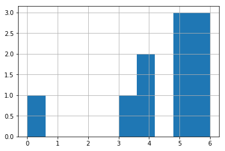

```python
s.hist()
```

# String Method

Series is equipped with a set of string processing methods in the str attribute that make it easy to operate on each element of the array, as in the code snippet below. Note that pattern-matching in str generally uses regular expressions by default (and in some cases always uses them). See more at Vectorized String Methods.

```python
s = pd.Series(['A', 'B', 'C', 'Aaba', 'Baca', np.nan, 'CABA', 'dog', 'cat'])
s.str.lower()
```

```
0       a
1       b
2       c
3    aaba
4    baca
5     NaN
6    caba
7     dog
8     cat
dtype: object
```

# Merge

## Concat

pandas provides various facilities for easily combining together Series, DataFrame, and Panel objects with various kinds of set logic for the indexes and relational algebra functionality in the case of join / merge-type operations. Concatenating pandas objects together with concat():

```python
df = pd.DataFrame(np.random.randn(10, 4))
df
```

|  | 0 | 1 | 2 | 3 |
| --- | --- | --- | --- | --- |
| 0 | -1.324569 | -1.234649 | -1.124129 | -0.504474 |
| 1 | 1.695431 | 0.413092 | -0.872270 | -1.364061 |
| 2 | -0.074597 | 0.989707 | -0.279127 | 0.804812 |
| 3 | -0.327334 | 0.683398 | -0.306069 | 0.655359 |
| 4 | -0.756864 | 1.693462 | 0.553428 | -0.770812 |
| 5 | 0.250843 | -0.329315 | -0.935587 | 1.204658 |
| 6 | -1.426603 | 1.163941 | 0.314563 | 0.310553 |
| 7 | 0.139997 | 0.316368 | 0.298542 | 3.293558 |
| 8 | -1.255067 | -0.459419 | -0.242739 | -0.781934 |
| 9 | 0.106537 | 0.523646 | -0.179513 | 0.210231 |

```python
pieces = [ df[:3],df[3:7],df[7:]]
pieces
```

```
[          0         1         2         3
 0 -1.324569 -1.234649 -1.124129 -0.504474
 1  1.695431  0.413092 -0.872270 -1.364061
 2 -0.074597  0.989707 -0.279127  0.804812,
           0         1         2         3
 3 -0.327334  0.683398 -0.306069  0.655359
 4 -0.756864  1.693462  0.553428 -0.770812
 5  0.250843 -0.329315 -0.935587  1.204658
 6 -1.426603  1.163941  0.314563  0.310553,
           0         1         2         3
 7  0.139997  0.316368  0.298542  3.293558
 8 -1.255067 -0.459419 -0.242739 -0.781934
 9  0.106537  0.523646 -0.179513  0.210231]
```

```python
pd.concat(pieces)
```

|  | 0 | 1 | 2 | 3 |
| --- | --- | --- | --- | --- |
| 0 | -1.324569 | -1.234649 | -1.124129 | -0.504474 |
| 1 | 1.695431 | 0.413092 | -0.872270 | -1.364061 |
| 2 | -0.074597 | 0.989707 | -0.279127 | 0.804812 |
| 3 | -0.327334 | 0.683398 | -0.306069 | 0.655359 |
| 4 | -0.756864 | 1.693462 | 0.553428 | -0.770812 |
| 5 | 0.250843 | -0.329315 | -0.935587 | 1.204658 |
| 6 | -1.426603 | 1.163941 | 0.314563 | 0.310553 |
| 7 | 0.139997 | 0.316368 | 0.298542 | 3.293558 |
| 8 | -1.255067 | -0.459419 | -0.242739 | -0.781934 |
| 9 | 0.106537 | 0.523646 | -0.179513 | 0.210231 |

# Join

```python
left = pd.DataFrame({'key': ['foo', 'foo'], 'lval': [1, 2]})
left
```

|  | key | lval |
| --- | --- | --- |
| 0 | foo | 1 |
| 1 | foo | 2 |

```python
right = pd.DataFrame({'key': ['foo', 'foo'], 'rval': [4, 5]})
right
```

|  | key | rval |
| --- | --- | --- |
| 0 | foo | 4 |
| 1 | foo | 5 |

```python
pd.merge(left,right,on='key')
```

|  | key | lval | rval |
| --- | --- | --- | --- |
| 0 | foo | 1 | 4 |
| 1 | foo | 1 | 5 |
| 2 | foo | 2 | 4 |
| 3 | foo | 2 | 5 |

```python
left = pd.DataFrame({'key': ['foo', 'bar'], 'lval': [1, 2]})
right = pd.DataFrame({'key': ['foo', 'bar'], 'rval': [4, 5]})
```

```python
left
```

|  | key | lval |
| --- | --- | --- |
| 0 | foo | 1 |
| 1 | bar | 2 |

```python
right
```

|  | key | rval |
| --- | --- | --- |
| 0 | foo | 4 |
| 1 | bar | 5 |

```python
pd.merge(left,right,on='key')
```

|  | key | lval | rval |
| --- | --- | --- | --- |
| 0 | foo | 1 | 4 |
| 1 | bar | 2 | 5 |

# Append

```python
df = pd.DataFrame(np.random.randn(8, 4), columns=['A','B','C','D'])
df
```

|  | A | B | C | D |
| --- | --- | --- | --- | --- |
| 0 | -1.537328 | 1.398373 | 0.423280 | -0.695441 |
| 1 | 0.202109 | 0.496236 | -1.010720 | 0.529397 |
| 2 | 0.472050 | 0.187170 | -1.013900 | -0.492509 |
| 3 | 0.395635 | -0.815634 | 2.006611 | 0.159452 |
| 4 | -0.316481 | -0.147320 | -1.677463 | 0.053279 |
| 5 | -0.149004 | -0.427456 | -0.689609 | 0.252234 |
| 6 | 0.279484 | 1.594766 | 0.153109 | 0.923148 |
| 7 | 0.824526 | 0.397604 | -0.659648 | -0.143042 |

```python
s = df.iloc[3]
s
```

```
A    0.395635
B   -0.815634
C    2.006611
D    0.159452
Name: 3, dtype: float64
```

```python
df.append(s, ignore_index=True)
```

|  | A | B | C | D |
| --- | --- | --- | --- | --- |
| 0 | -1.537328 | 1.398373 | 0.423280 | -0.695441 |
| 1 | 0.202109 | 0.496236 | -1.010720 | 0.529397 |
| 2 | 0.472050 | 0.187170 | -1.013900 | -0.492509 |
| 3 | 0.395635 | -0.815634 | 2.006611 | 0.159452 |
| 4 | -0.316481 | -0.147320 | -1.677463 | 0.053279 |
| 5 | -0.149004 | -0.427456 | -0.689609 | 0.252234 |
| 6 | 0.279484 | 1.594766 | 0.153109 | 0.923148 |
| 7 | 0.824526 | 0.397604 | -0.659648 | -0.143042 |
| 8 | 0.395635 | -0.815634 | 2.006611 | 0.159452 |

# Grouping

By “group by” we are referring to a process involving one or more of the following steps:

- Splitting the data into groups based on some criteria
- Applying a function to each group independently
- Combining the results into a data structure

```python
df = pd.DataFrame({
    'A' : ['foo', 'bar', 'foo', 'bar','foo', 'bar', 'foo', 'foo'],
    'B' : ['one', 'one', 'two', 'three', 'two', 'two', 'one', 'three'],
    'C' : np.random.randn(8),
    'D' : np.random.randn(8)  })
df
```

|  | A | B | C | D |
| --- | --- | --- | --- | --- |
| 0 | foo | one | 0.047511 | 1.132033 |
| 1 | bar | one | -0.577552 | -2.395841 |
| 2 | foo | two | -0.275494 | 0.190072 |
| 3 | bar | three | -1.180274 | 0.979022 |
| 4 | foo | two | 0.147996 | -0.196241 |
| 5 | bar | two | -0.136709 | 0.519059 |
| 6 | foo | one | 1.587514 | -0.988029 |
| 7 | foo | three | 0.211344 | -0.697952 |

```python
#Grouping and then applying the sum() function to the resulting groups.
df.groupby('A').sum()
```

| A | C | D |
| --- | --- | --- |
| bar | -1.894536 | -0.897760 |
| foo | 1.718871 | -0.560118 |

```python
#Grouping by multiple columns forms a hierarchical index, and again we can apply the sum function.
df.groupby(['A','B']).sum()
```

| A | B | C | D |
| --- | --- | --- | --- |
| bar | one | -0.577552 | -2.395841 |
|  | three | -1.180274 | 0.979022 |
|  | two | -0.136709 | 0.519059 |
| foo | one | 1.635025 | 0.144003 |
|  | three | 0.211344 | -0.697952 |
|  | two | -0.127498 | -0.006169 |

# Reshaping

### Stack

```python
tuples = list(zip(*[['bar', 'bar', 'baz', 'baz','foo', 'foo', 'qux', 'qux'], ['one', 'two', 'one', 'two','one', 'two', 'one', 'two']]))
tuples
```

```
[('bar', 'one'),
 ('bar', 'two'),
 ('baz', 'one'),
 ('baz', 'two'),
 ('foo', 'one'),
 ('foo', 'two'),
 ('qux', 'one'),
 ('qux', 'two')]
```

```python
index = pd.MultiIndex.from_tuples(tuples, names=['first', 'second'])
index
```

```
MultiIndex(levels=[['bar', 'baz', 'foo', 'qux'], ['one', 'two']],
           labels=[[0, 0, 1, 1, 2, 2, 3, 3], [0, 1, 0, 1, 0, 1, 0, 1]],
           names=['first', 'second'])
```

```python
df = pd.DataFrame(np.random.randn(8, 2), index=index, columns=['A', 'B'])
df
```

| first | second | A | B |
| --- | --- | --- | --- |
| bar | one | 2.226308 | 0.278404 |
|  | two | -1.581138 | 0.463740 |
| baz | one | -1.000637 | -1.474373 |
|  | two | -1.133506 | 0.149732 |
| foo | one | 0.521745 | 2.807082 |
|  | two | 0.606952 | 0.013871 |
| qux | one | 0.917132 | -2.731337 |
|  | two | -0.516795 | 0.734951 |

```python
df2 = df[:4]
df2
```

| first | second | A | B |
| --- | --- | --- | --- |
| bar | one | 2.226308 | 0.278404 |
|  | two | -1.581138 | 0.463740 |
| baz | one | -1.000637 | -1.474373 |
|  | two | -1.133506 | 0.149732 |

```python
#The stack() method “compresses” a level in the DataFrame’s columns.
stacked = df2.stack()
stacked
```

```
first  second
bar    one     A    2.226308
               B    0.278404
       two     A   -1.581138
               B    0.463740
baz    one     A   -1.000637
               B   -1.474373
       two     A   -1.133506
               B    0.149732
dtype: float64
```

```python
#With a “stacked” DataFrame or Series (having a MultiIndex as the index), the inverse operation of stack() is
#unstack(), which by default unstacks the last level:
stacked.unstack()
```

| first | second | A | B |
| --- | --- | --- | --- |
| bar | one | 2.226308 | 0.278404 |
|  | two | -1.581138 | 0.463740 |
| baz | one | -1.000637 | -1.474373 |
|  | two | -1.133506 | 0.149732 |

```python
stacked.unstack(1)
```

| first | second | one | two |
| --- | --- | --- | --- |
| bar | A | 2.226308 | -1.581138 |
|  | B | 0.278404 | 0.463740 |
| baz | A | -1.000637 | -1.133506 |
|  | B | -1.474373 | 0.149732 |

```python
stacked.unstack(0)
```

| second | first | bar | baz |
| --- | --- | --- | --- |
| one | A | 2.226308 | -1.000637 |
|  | B | 0.278404 | -1.474373 |
| two | A | -1.581138 | -1.133506 |
|  | B | 0.463740 | 0.149732 |

# Pivot Tables

```python
df = pd.DataFrame({
     'A' : ['one', 'one', 'two', 'three'] * 3,
     'B' : ['A', 'B', 'C'] * 4,
     'C' : ['foo', 'foo', 'foo', 'bar', 'bar', 'bar'] * 2,
     'D' : np.random.randn(12),
     'E' : np.random.randn(12)
                })
df
```

|  | A | B | C | D | E |
| --- | --- | --- | --- | --- | --- |
| 0 | one | A | foo | 1.736255 | -1.243646 |
| 1 | one | B | foo | 0.796856 | 0.449691 |
| 2 | two | C | foo | -0.115390 | 0.196244 |
| 3 | three | A | bar | 1.046835 | 1.412204 |
| 4 | one | B | bar | -1.555530 | 0.556258 |
| 5 | one | C | bar | 0.610906 | 0.308143 |
| 6 | two | A | foo | 0.263146 | 1.316757 |
| 7 | three | B | foo | -1.475000 | 1.671137 |
| 8 | one | C | foo | -0.341533 | 0.262783 |
| 9 | one | A | bar | -1.272910 | 0.461449 |
| 10 | two | B | bar | 1.121706 | 1.331716 |
| 11 | three | C | bar | -0.166159 | 0.253260 |

```python
#We can produce pivot tables from this data very easily:
pd.pivot_table(df, values='D', index=['A', 'B'], columns=['C'])
```

| A | C B | bar | foo |
| --- | --- | --- | --- |
| one | A | -1.272910 | 1.736255 |
|  | B | -1.555530 | 0.796856 |
|  | C | 0.610906 | -0.341533 |
| three | A | 1.046835 | NaN |
|  | B | NaN | -1.475000 |
|  | C | -0.166159 | NaN |
| two | A | NaN | 0.263146 |
|  | B | 1.121706 | NaN |
|  | C | NaN | -0.115390 |

# Time Series

pandas has simple, powerful, and efficient functionality for performing resampling operations during frequency conversion (e.g., converting secondly data into 5-minutely data). This is extremely common in, but not limited to, financial applications. See the Time Series section.

```python
rng = pd.date_range('1/1/2012', periods=100, freq='S')
ts = pd.Series(np.random.randint(0, 500, len(rng)), index=rng)
ts.resample('5Min').sum()
```

[output not shown]

```python
#Time zone representation:
rng = pd.date_range('3/6/2012 00:00', periods=5, freq='D')
ts = pd.Series(np.random.randn(len(rng)), rng)
ts
```

```
2012-03-06   -1.651859
2012-03-07    0.297984
2012-03-08   -2.094821
2012-03-09   -0.403315
2012-03-10   -0.072120
Freq: D, dtype: float64
```

```python
ts_utc = ts.tz_localize('UTC')
ts_utc
```

```
2012-03-06 00:00:00+00:00   -1.651859
2012-03-07 00:00:00+00:00    0.297984
2012-03-08 00:00:00+00:00   -2.094821
2012-03-09 00:00:00+00:00   -0.403315
2012-03-10 00:00:00+00:00   -0.072120
Freq: D, dtype: float64
```

```python
ts_utc.tz_convert('US/Eastern')
```

```
2012-03-05 19:00:00-05:00   -1.651859
2012-03-06 19:00:00-05:00    0.297984
2012-03-07 19:00:00-05:00   -2.094821
2012-03-08 19:00:00-05:00   -0.403315
2012-03-09 19:00:00-05:00   -0.072120
Freq: D, dtype: float64
```

```python
#Converting between time span representations:
rng = pd.date_range('1/1/2012', periods=5, freq='M')
ts = pd.Series(np.random.randn(len(rng)), index=rng)
ts
```

```
2012-01-31    0.661598
2012-02-29   -0.639810
2012-03-31    0.362031
2012-04-30    1.416207
2012-05-31    1.962709
Freq: M, dtype: float64
```

```python
ps = ts.to_period()
ps
```

```
2012-01    0.661598
2012-02   -0.639810
2012-03    0.362031
2012-04    1.416207
2012-05    1.962709
Freq: M, dtype: float64
```

```python
ps.to_timestamp()
```

```
2012-01-01    0.661598
2012-02-01   -0.639810
2012-03-01    0.362031
2012-04-01    1.416207
2012-05-01    1.962709
Freq: MS, dtype: float64
```

Converting between period and timestamp enables some convenient arithmetic functions to be used. In the following example, we convert a quarterly frequency with year ending in November to 9am of the end of the month following the quarter end:

```python
prng = pd.period_range('1990Q1', '2000Q4', freq='Q-NOV')
ts = pd.Series(np.random.randn(len(prng)), prng)
ts.index = (prng.asfreq('M', 'e') + 1).asfreq('H', 's') + 9
ts.head()
```

```
1990-03-01 09:00    2.844381
1990-06-01 09:00   -0.492159
1990-09-01 09:00    0.484018
1990-12-01 09:00    0.166060
1991-03-01 09:00   -0.597262
Freq: H, dtype: float64
```

# Categoricals

```python
df = pd.DataFrame({"id":[1,2,3,4,5,6], "raw_grade":['a', 'b', 'b', 'a', 'a','e']})
```

```python
#Convert the raw grades to a categorical data type
df["grade"] = df["raw_grade"].astype("category")
df["grade"]
```

```
0    a
1    b
2    b
3    a
4    a
5    e
Name: grade, dtype: category
Categories (3, object): [a, b, e]
```

```python
df["grade"].cat.categories = ["very good", "good", "very bad"]
df['grade']
```

```
0    very good
1         good
2         good
3    very good
4    very good
5     very bad
Name: grade, dtype: category
Categories (3, object): [very good, good, very bad]
```

```python
#Reorder the categories and simultaneously add the missing categories (methods under Series
#.cat return a newSeries by default)
df.sort_values(by="grade")
```

|  | id | raw_grade | grade |
| --- | --- | --- | --- |
| 0 | 1 | a | very good |
| 3 | 4 | a | very good |
| 4 | 5 | a | very good |
| 1 | 2 | b | good |
| 2 | 3 | b | good |
| 5 | 6 | e | very bad |

```python
#grouping data according to grade
df.groupby("grade").size()
```

```
grade
very good    3
good         2
very bad     1
dtype: int64
```

# Plotting

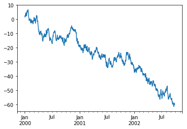

```python
%matplotlib inline
ts = pd.Series(np.random.randn(1000), index=pd.date_range('1/1/2000',periods=1000))
ts = ts.cumsum()
ts.plot()
```

```python
data = pd.DataFrame(np.random.normal(65.0,25.0,100).reshape(50,2))
```

```python
data.head()
```

|  | 0 | 1 |
| --- | --- | --- |
| 0 | 70.763823 | 28.633830 |
| 1 | 85.187298 | 70.643644 |
| 2 | 76.917893 | 22.260126 |
| 3 | 60.402084 | 33.551168 |
| 4 | 41.513613 | 92.093340 |

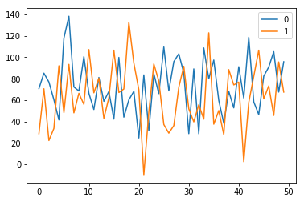

```python
data.plot()
```

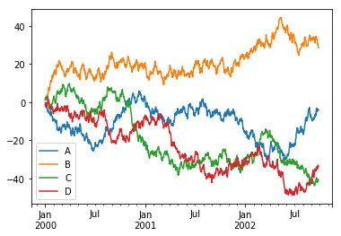

```python
from matplotlib import pyplot as plt
df = pd.DataFrame(np.random.randn(1000, 4), index=ts.index,columns=['A', 'B', 'C', 'D'])
df = df.cumsum()
plt.figure();df.plot();plt.legend(loc='best')
```

# Getting Data In/Out

## CSV

```python
df.to_csv('foo.csv')
```

```python
pd.read_csv('foo.csv').head()
```

|  | Unnamed: 0 | A | B | C | D |
| --- | --- | --- | --- | --- | --- |
| 0 | 2000-01-01 | -0.228509 | 1.015465 | 1.480305 | -1.371441 |
| 1 | 2000-01-02 | -2.271368 | 2.451973 | 2.468343 | -1.537067 |
| 2 | 2000-01-03 | -1.816118 | 1.136622 | 1.470017 | -1.445329 |
| 3 | 2000-01-04 | -2.097355 | 1.604628 | 2.085082 | -1.524939 |
| 4 | 2000-01-05 | -3.031952 | 2.724941 | 2.461877 | -0.316471 |

## HDF5

```python
df.to_hdf('foo.h5','df')
```

```python
pd.read_hdf('foo.h5','df').head()
```

|  | A | B | C | D |
| --- | --- | --- | --- | --- |
| 2000-01-01 | -0.228509 | 1.015465 | 1.480305 | -1.371441 |
| 2000-01-02 | -2.271368 | 2.451973 | 2.468343 | -1.537067 |
| 2000-01-03 | -1.816118 | 1.136622 | 1.470017 | -1.445329 |
| 2000-01-04 | -2.097355 | 1.604628 | 2.085082 | -1.524939 |
| 2000-01-05 | -3.031952 | 2.724941 | 2.461877 | -0.316471 |

## Excel

```python
df.to_excel('foo.xlsx',sheet_name='Sheet1')
```

```python
pd.read_excel('foo.xlsx','Sheet1',index_col=None,na_values=['NA']).head()
```

|  | A | B | C | D |
| --- | --- | --- | --- | --- |
| 2000-01-01 | -0.228509 | 1.015465 | 1.480305 | -1.371441 |
| 2000-01-02 | -2.271368 | 2.451973 | 2.468343 | -1.537067 |
| 2000-01-03 | -1.816118 | 1.136622 | 1.470017 | -1.445329 |
| 2000-01-04 | -2.097355 | 1.604628 | 2.085082 | -1.524939 |
| 2000-01-05 | -3.031952 | 2.724941 | 2.461877 | -0.316471 |

# Gotchas

```python
if pd.Series([False,True,False]):#.any() :
    print("I was True ")
else :
    print("I was Wrong")
#chapter 6 519
```

```
---------------------------------------------------------------------------
ValueError                                Traceback (most recent call last)
<ipython-input-273-aab4d6b583a4> in <module>()
----> 1 if pd.Series([False,True,False]):#.any() :
      2     print("I was True ")
      3 else :
      4     print("I was Wrong")

C:\ProgramData\Anaconda3\lib\site-packages\pandas\core\generic.py in __nonzero__(self)
   1571         raise ValueError("The truth value of a {0} is ambiguous. "
   1572                          "Use a.empty, a.bool(), a.item(), a.any() or a.all()."
-> 1573                          .format(self.__class__.__name__))
   1574
   1575     __bool__ = __nonzero__

ValueError: The truth value of a Series is ambiguous. Use a.empty, a.bool(), a.item(), a.any() or a.all().
```